# Exploring digital imbalance among female Kagglers in Africa

### Data used is Kaggle 2021 survey response

```python
import pandas as pd
```

```python
df = pd.read_csv('kaggle_survey_2021_responses.csv')
df.head()
```

|  | Time from Start to Finish (seconds) | Q1 | Q2 | Q3 | Q4 | Q5 | Q6 | Q7_Part_1 | Q7_Part_2 | Q7_Part_3 | Q7_Part_4 | Q7_Part_5 | Q7_Part_6 | Q7_Part_7 | Q7_Part_8 | Q7_Part_9 | Q7_Part_10 | Q7_Part_11 | Q7_Part_12 | Q7_OTHER | Q8 | Q9_Part_1 | Q9_Part_2 | Q9_Part_3 | Q9_Part_4 | Q9_Part_5 | Q9_Part_6 | Q9_Part_7 | Q9_Part_8 | … |
| --- | --- | --- | --- | --- | --- | --- | --- | --- | --- | --- | --- | --- | --- | --- | --- | --- | --- | --- | --- | --- | --- | --- | --- | --- | --- | --- | --- | --- | --- | --- |
| 0 | Duration (in seconds) | What is your age (# years)? | What is your gender? - Selected Choice | In which country do you currently reside? | What is the highest level of formal education ... | Select the title most similar to your current ... | For how many years have you been writing code ... | What programming languages do you use on a reg... | What programming languages do you use on a reg... | What programming languages do you use on a reg... | What programming languages do you use on a reg... | What programming languages do you use on a reg... | What programming languages do you use on a reg... | What programming languages do you use on a reg... | What programming languages do you use on a reg... | What programming languages do you use on a reg... | What programming languages do you use on a reg... | What programming languages do you use on a reg... | What programming languages do you use on a reg... | What programming languages do you use on a reg... | What programming language would you recommend ... | Which of the following integrated development ... | Which of the following integrated development ... | Which of the following integrated development ... | Which of the following integrated development ... | Which of the following integrated development ... | Which of the following integrated development ... | Which of the following integrated development ... | Which of the following integrated development ... | … |
| 1 | 910 | 50-54 | Man | India | Bachelor’s degree | Other | 5-10 years | Python | R | NaN | NaN | NaN | NaN | NaN | NaN | NaN | NaN | NaN | NaN | NaN | Python | NaN | NaN | NaN | NaN | NaN | NaN | NaN | NaN | … |
| 2 | 784 | 50-54 | Man | Indonesia | Master’s degree | Program/Project Manager | 20+ years | NaN | NaN | SQL | C | C++ | Java | NaN | NaN | NaN | NaN | NaN | NaN | NaN | Python | NaN | NaN | NaN | NaN | NaN | NaN | Notepad++ | NaN | … |
| 3 | 924 | 22-24 | Man | Pakistan | Master’s degree | Software Engineer | 1-3 years | Python | NaN | NaN | NaN | C++ | Java | NaN | NaN | NaN | NaN | NaN | NaN | NaN | Python | NaN | NaN | NaN | NaN | PyCharm | NaN | NaN | NaN | … |
| 4 | 575 | 45-49 | Man | Mexico | Doctoral degree | Research Scientist | 20+ years | Python | NaN | NaN | NaN | NaN | NaN | NaN | NaN | NaN | NaN | NaN | NaN | NaN | Python | NaN | NaN | NaN | NaN | NaN | Spyder | NaN | NaN | … |

5 rows × 369 columns

```python
df.shape
```

```
(25974, 369)
```

```python
df.columns
```

```
Index(['Time from Start to Finish (seconds)', 'Q1', 'Q2', 'Q3', 'Q4', 'Q5',
       'Q6', 'Q7_Part_1', 'Q7_Part_2', 'Q7_Part_3',
       ...
       'Q38_B_Part_3', 'Q38_B_Part_4', 'Q38_B_Part_5', 'Q38_B_Part_6',
       'Q38_B_Part_7', 'Q38_B_Part_8', 'Q38_B_Part_9', 'Q38_B_Part_10',
       'Q38_B_Part_11', 'Q38_B_OTHER'],
      dtype='object', length=369)
```

```python
#reading unique countries
df['Q3'].unique()
```

```
array(['In which country do you currently reside?', 'India', 'Indonesia',
       'Pakistan', 'Mexico', 'Russia', 'Turkey', 'Australia', 'Nigeria',
       'Greece', 'Belgium', 'Japan', 'Egypt', 'Singapore', 'Brazil',
       'Poland', 'China', 'Iran, Islamic Republic of...',
       'United States of America', 'Italy', 'Viet Nam', 'Israel', 'Peru',
       'South Africa', 'Other', 'Spain', 'Bangladesh',
       'United Kingdom of Great Britain and Northern Ireland', 'France',
       'Switzerland', 'Algeria', 'Tunisia', 'Argentina', 'Sweden',
       'Colombia', 'I do not wish to disclose my location', 'Canada',
       'Chile', 'Netherlands', 'Ukraine', 'Saudi Arabia', 'Romania',
       'Morocco', 'Austria', 'Taiwan', 'Kenya', 'Belarus', 'Ireland',
       'Portugal', 'Hong Kong (S.A.R.)', 'Denmark', 'Germany',
       'South Korea', 'Philippines', 'Sri Lanka', 'United Arab Emirates',
       'Uganda', 'Ghana', 'Malaysia', 'Thailand', 'Nepal', 'Kazakhstan',
       'Ethiopia', 'Iraq', 'Ecuador', 'Norway', 'Czech Republic'],
      dtype=object)
```

```python
len(df['Q3'].unique())
```

```
67
```

### Reading data for the years 2017 - 2020

```python
!ls
```

```
countries.xlsx	    kaggle-survey-2020			rapidsai-csp-utils
kaggle-survey-2017  kaggle_survey_2021_responses.csv	supplementary_data
kaggle-survey-2018  Kaggle_survey_responses_2021.ipynb
kaggle-survey-2019  notebooks
```

```python
df_2018 = pd.read_csv('./kaggle-survey-2018/multipleChoiceResponses.csv')
df_2019 = pd.read_csv('./kaggle-survey-2019/multiple_choice_responses.csv')
df_2020 = pd.read_csv('./kaggle-survey-2020/kaggle_survey_2020_responses.csv')
```

```python
print('Survey 2018: ', df_2018.shape)
print('Survey 2019: ', df_2019.shape)
print('Survey 2020: ', df_2020.shape)
print('Survey 2021: ', df.shape)
```

```
Survey 2018:  (23860, 395)
Survey 2019:  (19718, 246)
Survey 2020:  (20037, 355)
Survey 2021:  (25974, 369)
```

The survey received quite a high response in 2018. There was quite a drop in responses in 2019 and a slight increase in 2020. In 2021, the response was very high, exceeding all the previous years.

## Gender Distribution over the years

```python
# %age females in 2021
df['Q2'].value_counts()
```

```
Man                                       20598
Woman                                      4890
Prefer not to say                           355
Nonbinary                                    88
Prefer to self-describe                      42
What is your gender? - Selected Choice        1
Name: Q2, dtype: int64
```

```python
#%age femakes in 2020
df_2020['Q2'].value_counts()
```

```
Man                                       15789
Woman                                      3878
Prefer not to say                           263
Prefer to self-describe                      54
Nonbinary                                    52
What is your gender? - Selected Choice        1
Name: Q2, dtype: int64
```

```python
#%age females in df_2019
df_2019['Q2'].value_counts()
```

```
Male                                      16138
Female                                     3212
Prefer not to say                           318
Prefer to self-describe                      49
What is your gender? - Selected Choice        1
Name: Q2, dtype: int64
```

```python
#%age females in df_2019
df_2018['Q1'].value_counts()
```

```
Male                                      19430
Female                                     4010
Prefer not to say                           340
Prefer to self-describe                      79
What is your gender? - Selected Choice        1
Name: Q1, dtype: int64
```

### Female percentage

```python
#%age femakes in 2021
df['Q2'].value_counts(normalize = True)
```

```
Man                                       0.793024
Woman                                     0.188265
Prefer not to say                         0.013668
Nonbinary                                 0.003388
Prefer to self-describe                   0.001617
What is your gender? - Selected Choice    0.000039
Name: Q2, dtype: float64
```

```python
#%age femakes in 2020
df_2020['Q2'].value_counts(normalize = True)
```

```
Man                                       0.787992
Woman                                     0.193542
Prefer not to say                         0.013126
Prefer to self-describe                   0.002695
Nonbinary                                 0.002595
What is your gender? - Selected Choice    0.000050
Name: Q2, dtype: float64
```

```python
#%age femakes in 2019
df_2019['Q2'].value_counts(normalize = True)
```

```
Male                                      0.818440
Female                                    0.162897
Prefer not to say                         0.016127
Prefer to self-describe                   0.002485
What is your gender? - Selected Choice    0.000051
Name: Q2, dtype: float64
```

```python
#%age femakes in 2018
df_2018['Q1'].value_counts(normalize = True)
```

```
Male                                      0.814334
Female                                    0.168064
Prefer not to say                         0.014250
Prefer to self-describe                   0.003311
What is your gender? - Selected Choice    0.000042
Name: Q1, dtype: float64
```

```python
df.Q2.unique()
```

```
array(['What is your gender? - Selected Choice', 'Man', 'Woman',
       'Nonbinary', 'Prefer not to say', 'Prefer to self-describe'],
      dtype=object)
```

## Creating dataframes of females only

```python
# 2021
df_females = df.loc[df['Q2'] == 'Woman']
df_females.shape
```

```
(4890, 369)
```

```python
df_females.head(3)
```

|  | Time from Start to Finish (seconds) | Q1 | Q2 | Q3 | Q4 | Q5 | Q6 | Q7_Part_1 | Q7_Part_2 | Q7_Part_3 | Q7_Part_4 | Q7_Part_5 | Q7_Part_6 | Q7_Part_7 | Q7_Part_8 | Q7_Part_9 | Q7_Part_10 | Q7_Part_11 | Q7_Part_12 | Q7_OTHER | Q8 | Q9_Part_1 | Q9_Part_2 | Q9_Part_3 | Q9_Part_4 | Q9_Part_5 | Q9_Part_6 | Q9_Part_7 | Q9_Part_8 | … |
| --- | --- | --- | --- | --- | --- | --- | --- | --- | --- | --- | --- | --- | --- | --- | --- | --- | --- | --- | --- | --- | --- | --- | --- | --- | --- | --- | --- | --- | --- | --- |
| 6 | 1020 | 25-29 | Woman | India | I prefer not to answer | Currently not employed | < 1 years | Python | NaN | NaN | NaN | NaN | NaN | NaN | NaN | NaN | NaN | NaN | NaN | NaN | Python | Jupyter (JupyterLab, Jupyter Notebooks, etc) | NaN | NaN | NaN | PyCharm | Spyder | NaN | NaN | … |
| 7 | 141 | 18-21 | Woman | India | Some college/university study without earning ... | Student | 1-3 years | NaN | NaN | NaN | NaN | C++ | Java | Javascript | NaN | NaN | NaN | NaN | NaN | NaN | Python | NaN | NaN | Visual Studio | Visual Studio Code (VSCode) | NaN | NaN | NaN | NaN | … |
| 12 | 3081 | 18-21 | Woman | India | Master’s degree | Student | < 1 years | Python | R | NaN | NaN | C++ | NaN | NaN | NaN | NaN | NaN | NaN | NaN | NaN | R | NaN | RStudio | NaN | NaN | NaN | NaN | NaN | NaN | … |

3 rows × 369 columns

```python
#%age females
(4890/25974) * 100
```

```
18.826518826518825
```

The dataset has very few females, about 19% - check this answer wrt # of rows

```python
# 2020
df_females_2020 = df_2020.loc[df_2020['Q2'] == 'Woman']
df_females_2020.shape
```

```
(3878, 355)
```

```python
# 2019
df_females_2019 = df_2019.loc[df_2019['Q2'] == 'Female']
df_females_2019.shape
```

```
(3212, 246)
```

```python
# 2018
df_females_2018 = df_2018.loc[df_2018['Q1'] == 'Female']
df_females_2018.shape
```

```
(4010, 395)
```

## Different country categories

```python
#different categories of country
df_females['Q3'].value_counts()
```

```
India                                                   1656
United States of America                                 606
Other                                                    227
Egypt                                                    127
United Kingdom of Great Britain and Northern Ireland     113
                                                        ...
Kazakhstan                                                 7
Belarus                                                    6
Denmark                                                    6
Peru                                                       5
Ethiopia                                                   2
Name: Q3, Length: 66, dtype: int64
```

```
- we have 66 representation of countries where women reside
```

# How many women are from the African continent?

```python
pwd
```

```
'/content/drive/My Drive/Kaggle'
```

```python
%ls
```

```
countries.xlsx                    Kaggle_survey_responses_2021.ipynb
kaggle_survey_2021_responses.csv  supplementary_data/
```

```python
#reading an external file with countries in Africa and their capital cities
df_c = pd.read_excel('countries.xlsx')
df_c.head()
```

|  | Unnamed: 0 | Unnamed: 1 | Unnamed: 2 | Unnamed: 3 | Unnamed: 4 | Unnamed: 5 | Unnamed: 6 | Unnamed: 7 | Unnamed: 8 | Country | Capital | Unnamed: 11 |
| --- | --- | --- | --- | --- | --- | --- | --- | --- | --- | --- | --- | --- |
| 0 | NaN | NaN | NaN | NaN | NaN | NaN | NaN | NaN | NaN | 1.0 | Algeria | Algiers |
| 1 | NaN | NaN | NaN | NaN | NaN | NaN | NaN | NaN | NaN | 2.0 | Angola | Luanda |
| 2 | NaN | NaN | NaN | NaN | NaN | NaN | NaN | NaN | NaN | 3.0 | Benin | Porto-Novo |
| 3 | NaN | NaN | NaN | NaN | NaN | NaN | NaN | NaN | NaN | 4.0 | Botswana | Gaborone |
| 4 | NaN | NaN | NaN | NaN | NaN | NaN | NaN | NaN | NaN | 5.0 | Burkina Faso | Ouagadougou |

```python
cols = ['Capital', 'Unnamed: 11']
df_c = df_c[cols]
df_c.tail()
```

|  | Capital | Unnamed: 11 |
| --- | --- | --- |
| 52 | Togo | Lome |
| 53 | Tunisia | Tunis |
| 54 | Uganda | Kampala |
| 55 | Zambia | Lusaka |
| 56 | Zimbabwe | Harare |

```python
#renaming the columns
df_c.columns = ('Country', 'Capital')
df_c.sample(3)
```

|  | Country | Capital |
| --- | --- | --- |
| 48 | NaN | Bloemfontein (Judicial) |
| 51 | Tanzania | Dar es Salaam |
| 39 | Reunion | Saint-Denis |

```python
c_lst = df_c['Country']
c_lst.head()
```

```
0         Algeria
1          Angola
2           Benin
3        Botswana
4    Burkina Faso
Name: Country, dtype: object
```

## how many countries are represented by all the women in the dataset

```python
# how many countries are represented by all the women in the dataset
# how many women are in each country
unique_c = df_females['Q3'].value_counts()
len(unique_c)
```

```
66
```

```python
df_females.head(2)
```

|  | Time from Start to Finish (seconds) | Q1 | Q2 | Q3 | Q4 | Q5 | Q6 | Q7_Part_1 | Q7_Part_2 | Q7_Part_3 | Q7_Part_4 | Q7_Part_5 | Q7_Part_6 | Q7_Part_7 | Q7_Part_8 | Q7_Part_9 | Q7_Part_10 | Q7_Part_11 | Q7_Part_12 | Q7_OTHER | Q8 | Q9_Part_1 | Q9_Part_2 | Q9_Part_3 | Q9_Part_4 | Q9_Part_5 | Q9_Part_6 | Q9_Part_7 | Q9_Part_8 | … |
| --- | --- | --- | --- | --- | --- | --- | --- | --- | --- | --- | --- | --- | --- | --- | --- | --- | --- | --- | --- | --- | --- | --- | --- | --- | --- | --- | --- | --- | --- | --- |
| 6 | 1020 | 25-29 | Woman | India | I prefer not to answer | Currently not employed | < 1 years | Python | NaN | NaN | NaN | NaN | NaN | NaN | NaN | NaN | NaN | NaN | NaN | NaN | Python | Jupyter (JupyterLab, Jupyter Notebooks, etc) | NaN | NaN | NaN | PyCharm | Spyder | NaN | NaN | … |
| 7 | 141 | 18-21 | Woman | India | Some college/university study without earning ... | Student | 1-3 years | NaN | NaN | NaN | NaN | C++ | Java | Javascript | NaN | NaN | NaN | NaN | NaN | NaN | Python | NaN | NaN | Visual Studio | Visual Studio Code (VSCode) | NaN | NaN | NaN | NaN | … |

2 rows × 369 columns

```python
# 2018 to 2020

print('No: of countries with females reps')
print('2020: ', len(df_females_2020['Q3'].value_counts()))
print('2019: ', len(df_females_2019['Q3'].value_counts()))
print('2018: ', len(df_females_2019['Q3'].value_counts()))
```

```
No: of countries with females reps
2020:  55
2019:  59
2018:  59
```

```python
df_females['Q3'].value_counts()
```

```
India                                                   1656
United States of America                                 606
Other                                                    227
Egypt                                                    127
United Kingdom of Great Britain and Northern Ireland     113
                                                        ...
Nepal                                                      7
Denmark                                                    6
Belarus                                                    6
Peru                                                       5
Ethiopia                                                   2
Name: Q3, Length: 66, dtype: int64
```

```python
unique_c
```

```
India                                                   1656
United States of America                                 606
Other                                                    227
Egypt                                                    127
United Kingdom of Great Britain and Northern Ireland     113
                                                        ...
Nepal                                                      7
Denmark                                                    6
Belarus                                                    6
Peru                                                       5
Ethiopia                                                   2
Name: Q3, Length: 66, dtype: int64
```

```python
unique_c[0:3]
```

```
India                       1656
United States of America     606
Other                        227
Name: Q3, dtype: int64
```

```python
'India' in unique_c
```

```
True
```

```python
'India' in df_c
```

```
False
```

```python
unique_c.index[1]
```

```
'United States of America'
```

```python
j
```

```
0
```

## Which countries in Africa over the years

```python
f_in_Africa = []
j = 0

while j < len(df_c):
  for i in range(len(unique_c)):
    if unique_c.index[i] == df_c['Country'][j]:
        f_in_Africa.append([df_c['Country'][j], unique_c[i]])
  j += 1

print(f_in_Africa)
```

```
[['Algeria', 12], ['Egypt', 127], ['Ethiopia', 2], ['Ghana', 8], ['Kenya', 53], ['Morocco', 27], ['Nigeria', 107], ['South Africa', 28], ['Tunisia', 42], ['Uganda', 9]]
```

```python
print(len(f_in_Africa))
```

```
10
```

```python
#how many are they
cnt = 0

for i in range(len(f_in_Africa)):
  cnt += f_in_Africa[i][1]

cnt
```

```
415
```

```python
# %age of represented countries wrt all African countries
(len(f_in_Africa)/len(df_c)) * 100
```

```
17.543859649122805
```

```python
# %age of represented countries wrt to all countries where frmales reside
(len(f_in_Africa)/len(unique_c)) * 100
```

```
15.151515151515152
```

```python
# How many different countries are in the dataset?
len(df['Q3'].value_counts())
```

```
67
```

```
 - in terms of countries, we have female representatives in all but one country

 - it will be interesting to know which country is that
```

## Note: the output "In which country do you reside in in computations of %ages

```python
# finding the missing country where there are no representattives

all_c = df['Q3'].unique() # all the countries in the dataset

for i in range(len(all_c)):
    if ~(all_c[i] in unique_c):
        break    # break here

print('Country with no female reps is ' + all_c[i])
```

```
Country with no female reps is In which country do you currently reside?
```

```python
unique_c[0:10]
```

```
India                                                   1656
United States of America                                 606
Other                                                    227
Egypt                                                    127
United Kingdom of Great Britain and Northern Ireland     113
Nigeria                                                  107
China                                                    106
Russia                                                   104
Indonesia                                                 96
Pakistan                                                  81
Name: Q3, dtype: int64
```

```
 - all countries have female representatives (based on the above output)
```

## CONCLUSIONS 1

[output not shown]

```
   - Of the 57 African, only 10 countries are presented
```

```
 - these are Algeria, Egypt, Ethiopia, Ghana, Kenya, Morocco, Nigeria, South Africa, Tunisia and Uganda
```

```python
df_f_in_Africa = pd.DataFrame(f_in_Africa,columns=['Country', 'Total'])
df_f_in_Africa
```

|  | Country | Total |
| --- | --- | --- |
| 0 | Algeria | 12 |
| 1 | Egypt | 127 |
| 2 | Ethiopia | 2 |
| 3 | Ghana | 8 |
| 4 | Kenya | 53 |
| 5 | Morocco | 27 |
| 6 | Nigeria | 107 |
| 7 | South Africa | 28 |
| 8 | Tunisia | 42 |
| 9 | Uganda | 9 |

## CONCLUSIONS 2

```python
from matplotlib import pyplot as plt
```

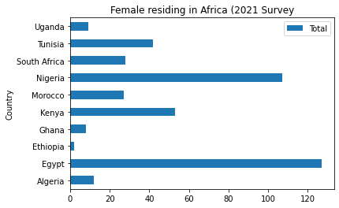

```python
df_f_in_Africa.plot.barh(x='Country', y='Total', title="Female residing in Africa (2021 Survey")

plt.show(block=True);
```

## Concentrating on females in Africa

```python
c_l = df_f_in_Africa['Country'].unique()
```

```python
print(unique_c[0:5])
print()
print(f_in_Africa[0:5])
```

```
India                                                   1656
United States of America                                 606
Other                                                    227
Egypt                                                    127
United Kingdom of Great Britain and Northern Ireland     113
Name: Q3, dtype: int64

[['Algeria', 12], ['Egypt', 127], ['Ethiopia', 2], ['Ghana', 8], ['Kenya', 53]]
```

```python
# which country has the most representation in all the 66 countries
max(unique_c)
```

```
1656
```

```python
# the least representations in all the 66 countries
min(unique_c)
```

```
2
```

## Are there any countries that are in tie with each of the 10 countries in Africa?

```python
for i in range(len(df_f_in_Africa)):
  if list(unique_c).count(df_f_in_Africa['Total'][i]) > 1:
    tie_c.append(df_f_in_Africa)
```

[output not shown]

```python
list(unique_c[0:3])
```

```
[1656, 606, 227]
```

```python
unique_c[0:3]
```

```
India                       1656
United States of America     606
Other                        227
Name: Q3, dtype: int64
```

```python
# searching if Ghana is in tie with other countries
list(unique_c).count(8)
```

```
7
```

```python
len(unique_c)
```

```
66
```

Ghana is in tie with 5 other countries --- as shown in the code below

```python
# countries in tie with Ghana

tie_with_Ghana = []

for i in range(len(unique_c)):
  if unique_c[i] == 8:
    tie_with_Ghana.append(unique_c.index[i])

print(tie_with_Ghana)
```

```
['Ghana', 'Belgium', 'I do not wish to disclose my location', 'Iraq', 'Ecuador', 'Austria', 'Ireland']
```

There are 8 females residing in Ghana who responded to the survey.

```
   - This small number is the same as the number of females residing in 5 other countries: Belgium, Iraq, Ecuador, Austria, Ireland

   - There are also 8 females who refered not to disclose their location
```

```python
# searching if Morocco is in tie with other countries
list(unique_c).count(27)
```

```
2
```

Morocco has the same female reps with another country --- in the sequel we find the other country

```python
# countries in tie with Morocco

tie_with_Morocco = []

for i in range(len(unique_c)):
  if unique_c[i] == 27:
    tie_with_Morocco.append(unique_c.index[i])

print(tie_with_Morocco)
```

```
['Morocco', 'Saudi Arabia']
```

There are 27 females from Morocco and 27 females from Saudi Arabia that responded to the survey

```python
# checking if South Africa is in tie with other countries
list(unique_c).count(28)
```

```
2
```

South Africa is in tie with another country --- in the sequel we find out which country it is

```python
# countries in tie with South Africa

tie_with_SA = []

for i in range(len(unique_c)):
  if unique_c[i] == 28:
    tie_with_SA.append(unique_c.index[i])

print(tie_with_SA)
```

```
['United Arab Emirates', 'South Africa']
```

There are 28 females residing in SA and 28 others residing in United Arab Emirates that responded to the survey

```python
# searching if Uganda is in tie with other countries
list(unique_c).count(9)
```

```
2
```

Uganda is in tie with another country ---- in the sequel we find out which country it is

```python
# countries in tie with Uganda

tie_with_Uganda = []

for i in range(len(unique_c)):
  if unique_c[i] == 9:
    tie_with_Uganda.append(unique_c.index[i])

print(tie_with_Uganda)
```

```
['Chile', 'Uganda']
```

Uganda is in tie with Chile

## OBSERVATION 3

```
- we have 4 African countries that have the same female representation as those in developed countries???

- we note the small number of responses

- we also have 6 other African countries who do not the same female reps as other countries with females who responded to the survey
```

```python
df_f_in_Africa
```

|  | Country | Total |
| --- | --- | --- |
| 0 | Algeria | 12 |
| 1 | Egypt | 127 |
| 2 | Ethiopia | 2 |
| 3 | Ghana | 8 |
| 4 | Kenya | 53 |
| 5 | Morocco | 27 |
| 6 | Nigeria | 107 |
| 7 | South Africa | 28 |
| 8 | Tunisia | 42 |
| 9 | Uganda | 9 |

## Concentrating only on the females residing in Africa

```
- can check if there could have been anyone who entered their capital city as well
```

```python
df_c.head(20)
```

|  | Country | Capital |
| --- | --- | --- |
| 0 | Algeria | Algiers |
| 1 | Angola | Luanda |
| 2 | Benin | Porto-Novo |
| 3 | Botswana | Gaborone |
| 4 | Burkina Faso | Ouagadougou |
| 5 | Burundi | Bujumbura |
| 6 | Cameroon | Yaounde |
| 7 | Cape Verde | Praia |
| 8 | Central African Republic | Bangui |
| 9 | Chad | N'Djamena |
| 10 | Comoros | Moroni |
| 11 | Congo | Brazzaville |
| 12 | Ivory Coast (Cote d'Ivoire) | Yamoussoukro |
| 13 | Djibouti | Djibouti |
| 14 | Egypt | Cairo |
| 15 | Equatorial Guinea | Malabo |
| 16 | Eritrea | Asmara |
| 17 | Ethiopia | Addis Ababa |
| 18 | Gabon | Libreville |
| 19 | Gambia | Banjul |

```python
# the different country list so as to see countries in Africa
c_lst = df_females['Q3'].value_counts()
c_lst
```

```
India                                                   1656
United States of America                                 606
Other                                                    227
Egypt                                                    127
United Kingdom of Great Britain and Northern Ireland     113
                                                        ...
Kazakhstan                                                 7
Denmark                                                    6
Belarus                                                    6
Peru                                                       5
Ethiopia                                                   2
Name: Q3, Length: 66, dtype: int64
```

```python
# creating a df with all females residing in Africa

df_fem_in_Africa = df_females[df_females['Q3'].isin(['Algeria','Tunisia','South Africa', 'Kenya', 'Uganda', 'Ethiopia', 'Egypt', 'Morocco','Nigeria','Ghana' ])]
df_fem_in_Africa.shape
```

```
(415, 369)
```

```python
# creating a df with females NOT residing in Africa
df_fem_not_in_Africa = df_females[~df_females['Q3'].isin(['Algeria','Tunisia','South Africa', 'Kenya', 'Uganda', 'Ethiopia', 'Egypt', 'Morocco','Nigeria','Ghana' ])]
df_fem_not_in_Africa.shape
```

```
(4475, 369)
```

```python
df_females.shape
```

```
(4890, 369)
```

# 2: Comparing females residing in Africa with those in

```
   - other countries
   - all females
```

## 2.1: Level of education

```python
# different levels of  education for all females
df_females['Q4'].value_counts()
```

```
Master’s degree                                                      1950
Bachelor’s degree                                                    1843
Doctoral degree                                                       565
Some college/university study without earning a bachelor’s degree     267
I prefer not to answer                                                140
Professional doctorate                                                 81
No formal education past high school                                   44
Name: Q4, dtype: int64
```

```python
# different levels of education for females residing in Africa
df_fem_in_Africa['Q4'].value_counts()
```

```
Bachelor’s degree                                                    184
Master’s degree                                                      139
Doctoral degree                                                       41
Some college/university study without earning a bachelor’s degree     33
I prefer not to answer                                                 9
Professional doctorate                                                 6
No formal education past high school                                   3
Name: Q4, dtype: int64
```

We have reps in all levels for females residing in Africa, with those with a Bachelor's degree toping the list

They are however followed closely by those females with a Master's degree

```python
#clean the data first
# which of females residing in Africa with a Bachelor's degree by country
#df_fem_in_Africa.loc[df_fem_in_Africa['Q4'] == 'Bachelor's degree']['Q3'].value_counts()
```

```python
a= list(df_fem_in_Africa['Q4'].head(1))
a
```

```
['Bachelor’s degree']
```

```python
len(a[0])
```

```
17
```

```python
b= list(df_fem_in_Africa['Q4'].head(2))
b
```

```
['Bachelor’s degree', 'Master’s degree']
```

```python
len(b[1])
```

```
15
```

```python
#different levels of education for females not residing in Africa
df_fem_not_in_Africa['Q4'].value_counts()
```

```
Master’s degree                                                      1811
Bachelor’s degree                                                    1659
Doctoral degree                                                       524
Some college/university study without earning a bachelor’s degree     234
I prefer not to answer                                                131
Professional doctorate                                                 75
No formal education past high school                                   41
Name: Q4, dtype: int64
```

the pattern is different for females in countries outside Africa with the majority having earned a Master's degree and these are closely followed by females with a Bachelors degree

however, we do not have many females with a Doctorate degree and professional doctorate

DS and ML seem to be attracting females with a Master's and a Bachelors

```python
df_fem_in_Africa.head(1)
```

|  | Time from Start to Finish (seconds) | Q1 | Q2 | Q3 | Q4 | Q5 | Q6 | Q7_Part_1 | Q7_Part_2 | Q7_Part_3 | Q7_Part_4 | Q7_Part_5 | Q7_Part_6 | Q7_Part_7 | Q7_Part_8 | Q7_Part_9 | Q7_Part_10 | Q7_Part_11 | Q7_Part_12 | Q7_OTHER | Q8 | Q9_Part_1 | Q9_Part_2 | Q9_Part_3 | Q9_Part_4 | Q9_Part_5 | Q9_Part_6 | Q9_Part_7 | Q9_Part_8 | … |
| --- | --- | --- | --- | --- | --- | --- | --- | --- | --- | --- | --- | --- | --- | --- | --- | --- | --- | --- | --- | --- | --- | --- | --- | --- | --- | --- | --- | --- | --- | --- |
| 34 | 744 | 30-34 | Woman | Egypt | Bachelor’s degree | Data Analyst | 3-5 years | Python | NaN | NaN | NaN | NaN | NaN | NaN | NaN | NaN | NaN | NaN | NaN | NaN | R | NaN | NaN | NaN | NaN | NaN | NaN | Notepad++ | NaN | … |

1 rows × 369 columns

## CREATING DATA FRAME FOR EACH REPRESENTED AFRICAN COUNTRY

```python
c = ['Egypt', 'Algeria', 'South Africa', 'Ethiopia', 'Uganda', 'Ghana', 'Kenya', 'Tunisia', 'Morocco', 'Nigeria']
```

```python
#creating a dataframe for Morocco
f_in_Morocco = df_fem_in_Africa.loc[df_fem_in_Africa['Q3'] == 'Morocco']
len(f_in_Morocco)
```

```
27
```

```python
#creating a dataframe for Kenya
f_in_Kenya = df_fem_in_Africa.loc[df_fem_in_Africa['Q3'] == 'Kenya']
print('Kenya: ', len(f_in_Kenya))
print()


#creating a dataframe for Kenya
f_in_Ghana = df_fem_in_Africa.loc[df_fem_in_Africa['Q3'] == 'Ghana']
print('Ghana: ', len(f_in_Ghana))
print()

#creating a dataframe for Ethiopia
f_in_Ethiopia = df_fem_in_Africa.loc[df_fem_in_Africa['Q3'] == 'Ethiopia']
print('Ethiopia: ', len(f_in_Ethiopia))
print()

#creating a dataframe for Algeria
f_in_Algeria = df_fem_in_Africa.loc[df_fem_in_Africa['Q3'] == 'Algeria']
print('Algeria: ', len(f_in_Algeria))
print()

#creating a dataframe for Uganda
f_in_Uganda = df_fem_in_Africa.loc[df_fem_in_Africa['Q3'] == 'Uganda']
print('Uganda: ', len(f_in_Uganda))
print()

#creating a dataframe for Nigeria
f_in_Nigeria = df_fem_in_Africa.loc[df_fem_in_Africa['Q3'] == 'Nigeria']
print('Nigeria: ', len(f_in_Nigeria))
print()

#creating a dataframe for Tunisia
f_in_Tunisia = df_fem_in_Africa.loc[df_fem_in_Africa['Q3'] == 'Tunisia']
print('Tunisia: ', len(f_in_Tunisia))
print()

#creating a dataframe for South Africa
f_in_SA = df_fem_in_Africa.loc[df_fem_in_Africa['Q3'] == 'South Africa']
print('South Africa: ', len(f_in_SA))
print()

#creating a dataframe for Egypt
f_in_Egypt = df_fem_in_Africa.loc[df_fem_in_Africa['Q3'] == 'Egypt']
print('Egypt: ', len(f_in_Egypt))
print()
```

```
Kenya:  53

Ghana:  8

Ethiopia:  2

Algeria:  12

Uganda:  9

Nigeria:  107

Tunisia:  42

South Africa:  28

Egypt:  127
```

### Looking at Noerthern Africa countries

```python
#fenale in Morocco based on their level of education
f_in_Morocco['Q4'].value_counts()
```

```
Master’s degree                                                      20
Doctoral degree                                                       3
Bachelor’s degree                                                     2
Some college/university study without earning a bachelor’s degree     1
I prefer not to answer                                                1
Name: Q4, dtype: int64
```

there were no responses from females with a professional doctorate and those with no formal education past high school from Morocco

```python
#fenale in Egypt based on their level of education
f_in_Egypt['Q4'].value_counts()
```

```
Bachelor’s degree                                                    62
Master’s degree                                                      26
Some college/university study without earning a bachelor’s degree    18
Doctoral degree                                                      13
I prefer not to answer                                                4
Professional doctorate                                                2
No formal education past high school                                  2
Name: Q4, dtype: int64
```

Egypt has responses from all levels

```python
#fenale in Algeria based on their level of education
f_in_Algeria['Q4'].value_counts()
```

```
Master’s degree                                                      5
Doctoral degree                                                      5
Some college/university study without earning a bachelor’s degree    1
Bachelor’s degree                                                    1
Name: Q4, dtype: int64
```

responses in Algeria were from only 4 out of the 7 categories

```python
#fenale in Tunisia based on their level of education
f_in_Tunisia['Q4'].value_counts()
```

```
Master’s degree           21
Doctoral degree            8
Bachelor’s degree          7
I prefer not to answer     4
Professional doctorate     2
Name: Q4, dtype: int64
```

Most of the Northern Africa represented countries have females that allready have their Master's degrees and Doctoral degrees

## Countries in West Africa wrt to level of education

```python
#fenale in Nigeria based on their level of education
f_in_Nigeria['Q4'].value_counts()
```

```
Bachelor’s degree                                                    53
Master’s degree                                                      42
Doctoral degree                                                       6
Some college/university study without earning a bachelor’s degree     5
No formal education past high school                                  1
Name: Q4, dtype: int64
```

The pattern change slightly as most female Kagglers in Nigeria only have a Bachelor's degree

```python
# Create dataframe for visualization of Q4
Q4_distrib = pd.DataFrame(f_in_Nigeria['Q4'].value_counts())
Q4_distrib.reset_index(inplace=True)
Q4_distrib_grey = Q4_distrib.copy()
Q4_distrib_grey = Q4_distrib_grey.replace(to_replace=2767, value=0)
```

```python
#fenale in Ghana based on their level of education
f_in_Ghana['Q4'].value_counts()
```

```
Bachelor’s degree                                                    4
Master’s degree                                                      3
Some college/university study without earning a bachelor’s degree    1
Name: Q4, dtype: int64
```

With the represented countries in Western Africa, the majority female Kagglers have a Bachelor's degree

### Females in Eastern Africa

```python
#fenale in Kenya based on their level of education
f_in_Kenya['Q4'].value_counts()
```

```
Bachelor’s degree                                                    35
Master’s degree                                                      11
Some college/university study without earning a bachelor’s degree     6
Professional doctorate                                                1
Name: Q4, dtype: int64
```

```python
#fenale in Uganda based on their level of education
f_in_Uganda['Q4'].value_counts()
```

```
Bachelor’s degree    5
Master’s degree      4
Name: Q4, dtype: int64
```

Uganda had responses ONLY from females with a Bachelor's degree followed closely by those with a Master's degree

```python
#fenale in Ethiopia based on their level of education
f_in_Ethiopia['Q4'].value_counts()
```

```
Master’s degree      1
Bachelor’s degree    1
Name: Q4, dtype: int64
```

The only two responses from Ethiopia were from female Kagglers with a Masters and with a Bachelors

### level of education : South Africa

```python
#fenale in South Africa based on their level of education
f_in_SA['Q4'].value_counts()
```

```
Bachelor’s degree                                                    14
Master’s degree                                                       6
Doctoral degree                                                       6
Professional doctorate                                                1
Some college/university study without earning a bachelor’s degree     1
Name: Q4, dtype: int64
```

The majprity of female kagglers in the represented countries in Northern Africa that hold a Master’s degree top the list. The scenery is very different with from other represented sub-regions whereby the majority of responses were received from females who hold a Bachelors degree.

```python
# women in each represented African country by their level of education
f_in_Africa = []
j = 0

while j < len(df_c):
  for i in range(len(df_fem_in_Africa)):
    if df_fem_in_Africa['Q4'][i] == df_c['Country'][j]:
        f_in_Africa.append([df_c['Country'][j], unique_c[i]])
  j += 1

print(f_in_Africa)
```

## DIFFERENT PROFESSIONS

```python
# different proffesions
df_females['Q5'].value_counts()
```

```
Student                         1574
Data Scientist                   584
Data Analyst                     505
Currently not employed           463
Other                            429
Software Engineer                366
Research Scientist               274
Machine Learning Engineer        179
Business Analyst                 175
Data Engineer                     98
Program/Project Manager           91
Statistician                      71
Product Manager                   45
DBA/Database Engineer             20
Developer Relations/Advocacy      16
Name: Q5, dtype: int64
```

```
     - female students are the majority followed by Data Scientists followed by Data Analysts
```

```python
# profession distribution of females in Africa
df_fem_in_Africa['Q5'].value_counts()
```

```
Student                      103
Data Scientist                69
Currently not employed        53
Data Analyst                  48
Software Engineer             32
Other                         32
Research Scientist            31
Machine Learning Engineer     14
Business Analyst              13
Statistician                   9
Program/Project Manager        5
Data Engineer                  4
Product Manager                2
Name: Q5, dtype: int64
```

Students top the list

```python
# which countries do the students in Africa come from?
df_fem_in_Africa.loc[df_fem_in_Africa['Q5'] == 'Student']['Q3'].value_counts()
```

```
Egypt           34
Nigeria         19
Tunisia         14
Kenya           10
Morocco          9
South Africa     6
Algeria          5
Ghana            4
Uganda           2
Name: Q3, dtype: int64
```

There are no female students from Ethiopia that completed the survey

```python
# which countries do DS  in Africa come from?
df_fem_in_Africa.loc[df_fem_in_Africa['Q5'] == 'Data Scientist']['Q3'].value_counts()
```

```
Nigeria         20
Egypt           13
Tunisia         12
Kenya           10
Morocco          8
South Africa     4
Uganda           2
Name: Q3, dtype: int64
```

There are no DS female reps from Algeria, Ghana and Ethiopia

Nigeria tops the list, closely by Egypt, Tunisia and Kenya

```python
# how many females in Africa are currently unemployed per country
df_fem_in_Africa.loc[df_fem_in_Africa['Q5'] == 'Currently not employed']['Q3'].value_counts()
```

```
Nigeria         16
Egypt           16
Kenya            9
Uganda           4
South Africa     3
Ghana            2
Tunisia          2
Morocco          1
Name: Q3, dtype: int64
```

We do not have anyone unemployed from Ethiopia and Algeria

```python
# how many females in Africa are Data Anaysts
df_fem_in_Africa.loc[df_fem_in_Africa['Q5'] == 'Data Analyst']['Q3'].value_counts()
```

```
Nigeria         18
Kenya           13
Egypt           13
South Africa     3
Tunisia          1
Name: Q3, dtype: int64
```

Nigeria, Kenya and Egypt still top the list wrt the above categories

There is still no rep from Ethiopia in this category

```python
# how many females in Africa are Software Engineers?
df_fem_in_Africa.loc[df_fem_in_Africa['Q5'] == 'Software Engineer']['Q3'].value_counts()
```

```
Egypt           10
Nigeria          8
Kenya            5
Tunisia          5
South Africa     1
Algeria          1
Morocco          1
Ethiopia         1
Name: Q3, dtype: int64
```

We have a single software Engineer from each one of the following countries: Ethiopia, Morocco, Algeria and SA

There is no Software Engineer from Ghana and Uganda

```python
# how many females in Africa are Research Scientists
df_fem_in_Africa.loc[df_fem_in_Africa['Q5'] == 'Research Scientist']['Q3'].value_counts()
```

```
Egypt           14
Algeria          5
Nigeria          4
Tunisia          3
South Africa     2
Morocco          2
Kenya            1
Name: Q3, dtype: int64
```

No rep from Ethiopia, Ghana and Uganda in this category

```python
# how many females in Africa are Macine Learning Engineers
df_fem_in_Africa.loc[df_fem_in_Africa['Q5'] == 'Machine Learning Engineer']['Q3'].value_counts()
```

```
Egypt      9
Tunisia    3
Morocco    1
Nigeria    1
Name: Q3, dtype: int64
```

few reps in this category in just 4 countries

```python
# how many females in Africa are Program/Project Managers
df_fem_in_Africa.loc[df_fem_in_Africa['Q5'] == 'Program/Project Manager']['Q3'].value_counts()
```

```
Nigeria    2
Egypt      2
Morocco    1
Name: Q3, dtype: int64
```

very few reps in this category again (3 countries)

```python
# how many females in Africa are Product Manager
df_fem_in_Africa.loc[df_fem_in_Africa['Q5'] == 'Product Manager']['Q3'].value_counts()
```

```
Nigeria    2
Name: Q3, dtype: int64
```

All Product Managers from females residing in Africa are from Nigera

```python
# how many females in Africa are Statisticians
df_fem_in_Africa.loc[df_fem_in_Africa['Q5'] == 'Statistician']['Q3'].value_counts()
```

```
South Africa    2
Morocco         2
Kenya           2
Egypt           2
Nigeria         1
Name: Q3, dtype: int64
```

There are 2 statisticians from each of the following countries: SA, Morocco, Kenya, Egypt and 1 from Nigeria

```python
# how many females in Africa are Data Engineers
df_fem_in_Africa.loc[df_fem_in_Africa['Q5'] == 'Data Engineer']['Q3'].value_counts()
```

```
Nigeria         2
Kenya           1
South Africa    1
Name: Q3, dtype: int64
```

very few reps in this category from 3 African countries

```python
# how many females in Africa are Business Anaysts
df_fem_in_Africa.loc[df_fem_in_Africa['Q5'] == 'Business Analyst']['Q3'].value_counts()
```

```
Egypt           6
Nigeria         3
Algeria         1
South Africa    1
Uganda          1
Kenya           1
Name: Q3, dtype: int64
```

No reps from Ethiopia, Ghana, Morocco, Tunisia

```python
# how many females in Africa did not enter their profession
df_fem_in_Africa.loc[df_fem_in_Africa['Q5'] == 'Other']['Q3'].value_counts()
```

```
Nigeria         11
Egypt            8
South Africa     5
Ghana            2
Tunisia          2
Morocco          2
Kenya            1
Ethiopia         1
Name: Q3, dtype: int64
```

```python
df_f_in_Africa
```

|  | Country | Total |
| --- | --- | --- |
| 0 | Algeria | 12 |
| 1 | Egypt | 127 |
| 2 | Ethiopia | 2 |
| 3 | Ghana | 8 |
| 4 | Kenya | 53 |
| 5 | Morocco | 27 |
| 6 | Nigeria | 107 |
| 7 | South Africa | 28 |
| 8 | Tunisia | 42 |
| 9 | Uganda | 9 |

```python
# profeesion distribution of females outside Africa
df_fem_not_in_Africa['Q5'].value_counts()
```

```
Student                         1471
Data Scientist                   515
Data Analyst                     457
Currently not employed           410
Other                            397
Software Engineer                334
Research Scientist               243
Machine Learning Engineer        165
Business Analyst                 162
Data Engineer                     94
Program/Project Manager           86
Statistician                      62
Product Manager                   43
DBA/Database Engineer             20
Developer Relations/Advocacy      16
Name: Q5, dtype: int64
```

```python
# how long have female participants been in the field
df_females['Q6'].value_counts()
```

```
1-3 years                    1565
< 1 years                    1418
3-5 years                     720
5-10 years                    485
I have never written code     283
10-20 years                   276
20+ years                     143
Name: Q6, dtype: int64
```

```python
df_fem_in_Africa['Q6'].value_counts()
```

```
1-3 years                    162
< 1 years                    135
3-5 years                     49
I have never written code     33
5-10 years                    23
10-20 years                   10
20+ years                      3
Name: Q6, dtype: int64
```

Pattern is the same: we lack females with experience

```python
# how many females in Africa are Data Anaysts
df_fem_in_Africa.loc[df_fem_in_Africa['Q6'] == 'I have never written code']['Q3'].value_counts()
```

```
Nigeria         13
Egypt            8
South Africa     3
Kenya            3
Tunisia          3
Morocco          2
Uganda           1
Name: Q3, dtype: int64
```

```python
# how many female participants prefer Python as a Programming language
df_females['Q7_Part_1'].value_counts()
```

```
Python    3877
Name: Q7_Part_1, dtype: int64
```

```
    - Of 4000+ women, more than half prefer Python as a Programming language
```

```python
# how many female participants from Africa prefer Python as a Programming language
df_fem_in_Africa['Q7_Part_1'].value_counts()
```

```
Python    322
Name: Q7_Part_1, dtype: int64
```

Python remains a popular language

```python
# usage of Python in Africa by females
# how many female participants prefer Python as a Programming language
df_fem_in_Africa.loc[df_fem_in_Africa['Q7_Part_1']=='Python']['Q3'].value_counts()
```

```
Egypt           106
Nigeria          78
Tunisia          35
Kenya            35
Morocco          24
South Africa     19
Algeria          12
Uganda            8
Ghana             4
Ethiopia          1
Name: Q3, dtype: int64
```

All African countries have reps

```python
# how many female participants prefer R as a Programming language
df_females['Q7_Part_2'].value_counts()
```

```
R    1145
Name: Q7_Part_2, dtype: int64
```

```python
# usage of R in Africa by females
# how many female participants prefer R as a Programming language
df_fem_in_Africa.loc[df_fem_in_Africa['Q7_Part_2']=='R']['Q3'].value_counts()
```

```
Kenya           26
Egypt           18
Nigeria         15
South Africa     7
Morocco          7
Tunisia          6
Algeria          4
Uganda           4
Ghana            1
Ethiopia         1
Name: Q3, dtype: int64
```

R is also popular and has reps in all African countries

```python
df_females.shape
```

```
(4890, 369)
```

```python
4890 - 3877
```

```
1013
```

```
   - R language is not that popular, but we seem to be having some female participants prefering more than one language

   - because from the 1013 remaining women who do not prefer Python, there is an excess of 132
```

```python
df_females['Q7_Part_1'][6]
```

```
'Python'
```

```python
range(6:10)
```